# Unit 1 - Assignement

GT

16 avril 2016

## AN ANALYTICAL DETECTIVE

### Problem 1 - Loading the Data

```r
Sys.setlocale("LC_ALL", "C")
```

```
## [1] "LC_CTYPE=C;LC_NUMERIC=C;LC_TIME=C;LC_COLLATE=C;LC_MONETARY=C;LC_MESSAGES=fr_FR.UTF-8;LC_PAPER=fr_FR.UTF-8;LC_NAME=C;LC_ADDRESS=C;LC_TELEPHONE=C;LC_MEASUREMENT=fr_FR.UTF-8;LC_IDENTIFICATION=C"
```

```r
mvt = read.csv("mvtWeek1.csv")
str(mvt)
```

```
## 'data.frame':    191641 obs. of  11 variables:
##  $ ID                 : int  8951354 8951141 8952745 8952223 8951608 8950793 8950760 8951611 8951802 8950706 ...
##  $ Date               : Factor w/ 131680 levels "1/1/01 0:01",..: 42823 42822 42822 42822 42821 42820 42819 42818 42816 42815 ...
##  $ LocationDescription: Factor w/ 78 levels "ABANDONED BUILDING",..: 72 72 62 72 72 72 72 72 72 72 ...
##  $ Arrest             : logi  FALSE FALSE FALSE FALSE FALSE TRUE ...
##  $ Domestic           : logi  FALSE FALSE FALSE FALSE FALSE FALSE ...
##  $ Beat               : int  623 1213 1622 724 211 2521 423 231 1021 1215 ...
##  $ District           : int  6 12 16 7 2 25 4 2 10 12 ...
##  $ CommunityArea      : int  69 24 11 67 35 19 48 40 29 24 ...
##  $ Year               : int  2012 2012 2012 2012 2012 2012 2012 2012 2012 2012 ...
##  $ Latitude           : num  41.8 41.9 42 41.8 41.8 ...
##  $ Longitude          : num  -87.6 -87.7 -87.8 -87.7 -87.6 ...
```

```r
summary(mvt)
```

```
##        ID                      Date
##  Min.   :1310022   5/16/08 0:00  :    11
##  1st Qu.:2832144   10/17/01 22:00:    10
##  Median :4762956   4/13/04 21:00 :    10
##  Mean   :4968629   9/17/05 22:00 :    10
##  3rd Qu.:7201878   10/12/01 22:00:     9
##  Max.   :9181151   10/13/01 22:00:     9
##                    (Other)       :191582
##                      LocationDescription   Arrest         Domestic
##  STREET                        :156564   Mode :logical   Mode :logical
##  PARKING LOT/GARAGE(NON.RESID.): 14852   FALSE:176105    FALSE:191226
##  OTHER                         :  4573   TRUE :15536     TRUE :415
##  ALLEY                         :  2308   NA's :0         NA's :0
##  GAS STATION                   :  2111
##  DRIVEWAY - RESIDENTIAL        :  1675
##  (Other)                       :  9558
##       Beat         District     CommunityArea        Year
##  Min.   : 111   Min.   : 1.00   Min.   : 0      Min.   :2001
##  1st Qu.: 722   1st Qu.: 6.00   1st Qu.:22      1st Qu.:2003
##  Median :1121   Median :10.00   Median :32      Median :2006
##  Mean   :1259   Mean   :11.82   Mean   :38      Mean   :2006
##  3rd Qu.:1733   3rd Qu.:17.00   3rd Qu.:60      3rd Qu.:2009
##  Max.   :2535   Max.   :31.00   Max.   :77      Max.   :2012
##                 NA's   :43056   NA's   :24616
##     Latitude       Longitude
##  Min.   :41.64   Min.   :-87.93
##  1st Qu.:41.77   1st Qu.:-87.72
##  Median :41.85   Median :-87.68
##  Mean   :41.84   Mean   :-87.68
##  3rd Qu.:41.92   3rd Qu.:-87.64
##  Max.   :42.02   Max.   :-87.52
##  NA's   :2276    NA's   :2276
```

How many observations ? **191641**

How many variables ? **11**

What is the maximum value of the variable “ID” ? **9181151**

What is the minimum value of the variable “Beat” ? **111**

How many obs have value TRUE in the “Arrest” variables ? **15536**

How many observations have a LocationDescription value of ALLEY ? **2308**

### Problem 2 - Understanding Dates in R

In what format are the entries in the variable Date ? **mm/dd/yy hh:mm**

```r
mvt$Date[1]
```

```
## [1] 12/31/12 23:15
## 131680 Levels: 1/1/01 0:01 1/1/01 0:05 1/1/01 0:30 ... 9/9/12 9:50
```

Let’s convert these characters into a Date object in R.

```r
DateConvert = as.Date(strptime(mvt$Date, "%m/%d/%y %H:%M"))
summary(DateConvert)
```

```
##         Min.      1st Qu.       Median         Mean      3rd Qu.
## "2001-01-01" "2003-07-10" "2006-05-21" "2006-08-23" "2009-10-24"
##         Max.
## "2012-12-31"
```

What’s the month of the year of the median date in the dataset ? **May 2006**

Let’s extract the month and the day of the week, and add these variables to the data.

```r
mvt$Month = months(DateConvert)
mvt$Weekday = weekdays(DateConvert)
mvt$Date = DateConvert
table(mvt$Month)
```

```
##
##     April    August  December  February   January      July      June
##     15280     16572     16426     13511     16047     16801     16002
##     March       May  November   October September
##     15758     16035     16063     17086     16060
```

```r
table(mvt$Weekday)
```

```
##
##    Friday    Monday  Saturday    Sunday  Thursday   Tuesday Wednesday
##     29284     27397     27118     26316     27319     26791     27416
```

```r
table(mvt$Month, mvt$Arrest)
```

```
##
##             FALSE  TRUE
##   April     14028  1252
##   August    15243  1329
##   December  15029  1397
##   February  12273  1238
##   January   14612  1435
##   July      15477  1324
##   June      14772  1230
##   March     14460  1298
##   May       14848  1187
##   November  14807  1256
##   October   15744  1342
##   September 14812  1248
```

In which month did the fewest motor vehicle thefts occur ? **February**

On which weekday did the most motor vehicle thefts occur ? **Friday**

Which month has the largest number of motor vehicle thefts for which an arrest was made ? **January**

### Problem 3 - Visualizing Crime Trends

Make a histogram of the variable Date. Add an extra argument, to specify the number of bars we want into histogram

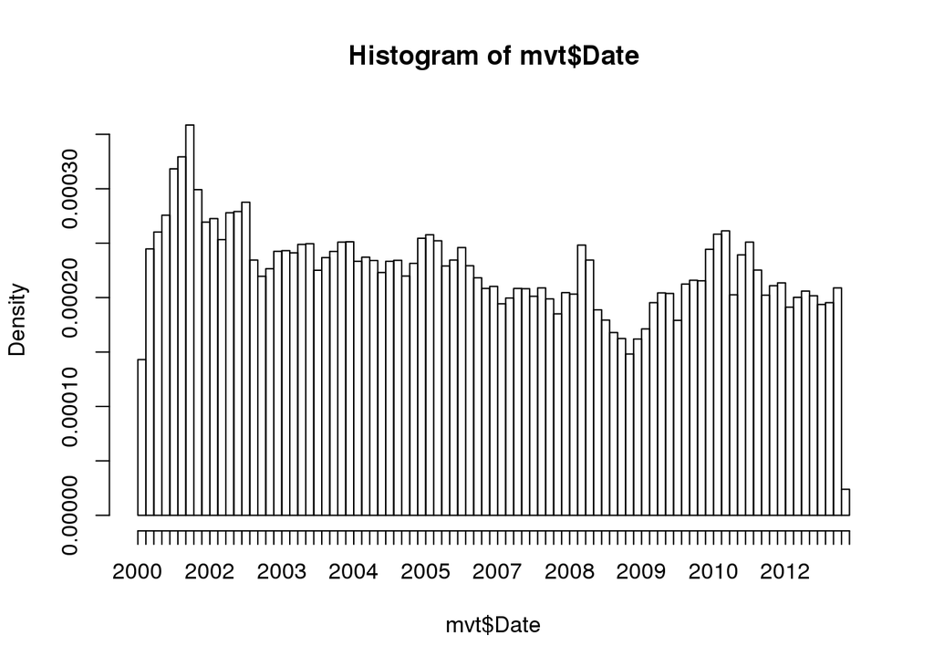

```r
hist(mvt$Date, breaks=100)
```

Does it look like crime increase or decrease from 2002-2012 ? **Decrease**

Does it look like crime increase or decrease frome 2005-2008 ? **Decrease**

Does it look like crime increase or decrease from 2009-2011 ? **Increase**

Create a boxplot of the variable “Date”, sorted by the variable “Arrest”

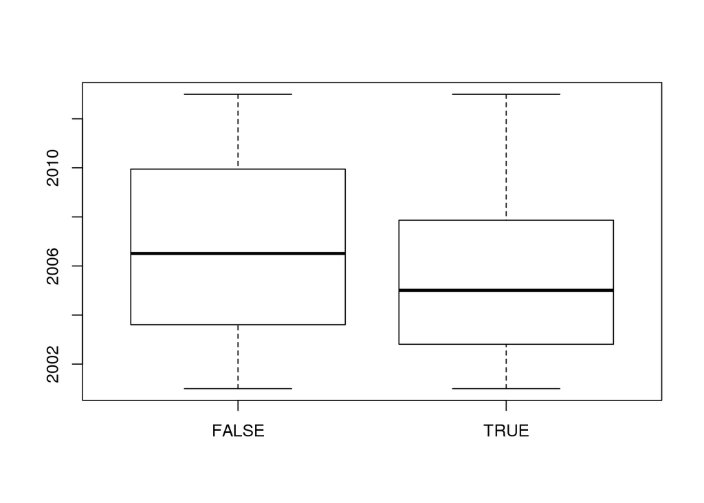

```r
boxplot(mvt$Date ~ mvt$Arrest)
```

Does it look like there were more crimes for which arrests were made in the first half of the time period or the second half ? **First half**

```r
table(mvt$Year, mvt$Arrest)
```

```
##
##        FALSE  TRUE
##   2001 18517  2152
##   2002 16638  2115
##   2003 14859  1798
##   2004 15169  1693
##   2005 14956  1528
##   2006 14796  1302
##   2007 13068  1212
##   2008 13425  1020
##   2009 11327   840
##   2010 14796   701
##   2011 15012   625
##   2012 13542   550
```

```r
Arrest2001 = subset(mvt, mvt$Year == 2001 & mvt$Arrest == TRUE)
Total2001 = subset(mvt, mvt$Year == 2001)
nrow(Arrest2001)/nrow(Total2001)
```

```
## [1] 0.1041173
```

```r
Arrest2007 = subset(mvt, mvt$Year == 2007 & mvt$Arrest == TRUE)
Total2007 = subset(mvt, mvt$Year == 2007)
nrow(Arrest2007)/nrow(Total2007)
```

```
## [1] 0.08487395
```

```r
Arrest2012 = subset(mvt, mvt$Year == 2012 & mvt$Arrest == TRUE)
Total2012 = subset(mvt, mvt$Year == 2012)
nrow(Arrest2012)/nrow(Total2012)
```

```
## [1] 0.03902924
```

For what proportion of motor vehicle thefts in 2001 was an arrest made? **0.104**

For what proportion of motor vehicle thefts in 2007 was an arrest made? **0.085**

For what proportion of motor vehicle thefts in 2012 was an arrest made? **0.039**

### Problem 4 - Popular Locations

Find the top five locations where motor vehicle thefts occur more by using the sort function: **Street, Parking Lot/Garage (Non. Resid.), Alley, Gas Station, and Driveway - Residential**

```r
sort(table(mvt$LocationDescription),decreasing = TRUE)
```

```
##
##                                          STREET
##                                          156564
##                  PARKING LOT/GARAGE(NON.RESID.)
##                                           14852
##                                           OTHER
##                                            4573
##                                           ALLEY
##                                            2308
##                                     GAS STATION
##                                            2111
##                          DRIVEWAY - RESIDENTIAL
##                                            1675
##                   RESIDENTIAL YARD (FRONT/BACK)
##                                            1536
##                                       RESIDENCE
##                                            1302
##                                RESIDENCE-GARAGE
##                                            1176
##                                 VACANT LOT/LAND
##                                             985
##                          VEHICLE NON-COMMERCIAL
##                                             817
##                                        SIDEWALK
##                                             462
##                         CHA PARKING LOT/GROUNDS
##                                             405
##                                AIRPORT/AIRCRAFT
##                                             363
##                 POLICE FACILITY/VEH PARKING LOT
##                                             266
##                                   PARK PROPERTY
##                                             255
##                         SCHOOL, PUBLIC, GROUNDS
##                                             206
##                                       APARTMENT
##                                             184
##                            SPORTS ARENA/STADIUM
##                                             166
##                     CTA GARAGE / OTHER PROPERTY
```

[output cut: 102 more lines]

```
##                                               2
##     AIRPORT BUILDING NON-TERMINAL - SECURE AREA
##                                               1
##                  AIRPORT EXTERIOR - SECURE AREA
##                                               1
##                                 ANIMAL HOSPITAL
##                                               1
##                                 APPLIANCE STORE
##                                               1
##                                       CTA TRAIN
##                                               1
##                         JAIL / LOCK-UP FACILITY
##                                               1
##                                       NEWSSTAND
##                                               1
```

Create a subset of your data, only taking observations for which the theft happened in one of these five locations

```r
Top5 = subset(mvt, mvt$LocationDescription %in% c("STREET", "PARKING LOT/GARAGE(NON.RESID.)", "ALLEY", "GAS STATION", "DRIVEWAY - RESIDENTIAL"))
nrow(mvt)
```

```
## [1] 191641
```

```r
nrow(Top5)
```

```
## [1] 177510
```

How many obs are in Top5 **177510**

R will remember the other categories of the LocationDescription variable from the orginal dataset. To make the tables nicer we can refresh this factor variable

```r
Top5$LocationDescription = factor(Top5$LocationDescription)
table(Top5$LocationDescription, Top5$Arrest)
```

```
##
##                                   FALSE   TRUE
##   ALLEY                            2059    249
##   DRIVEWAY - RESIDENTIAL           1543    132
##   GAS STATION                      1672    439
##   PARKING LOT/GARAGE(NON.RESID.)  13249   1603
##   STREET                         144969  11595
```

```r
table(Top5$Weekday, Top5$LocationDescription)
```

```
##
##             ALLEY DRIVEWAY - RESIDENTIAL GAS STATION
##   Friday      385                    257         332
##   Monday      320                    255         280
##   Saturday    341                    202         338
##   Sunday      307                    221         336
##   Thursday    315                    263         282
##   Tuesday     323                    243         270
##   Wednesday   317                    234         273
##
##             PARKING LOT/GARAGE(NON.RESID.) STREET
##   Friday                              2331  23773
##   Monday                              2128  22305
##   Saturday                            2199  22175
##   Sunday                              1936  21756
##   Thursday                            2082  22296
##   Tuesday                             2073  21888
##   Wednesday                           2103  22371
```

One of the locations has a much higher arrest rate than the other locations. Which is it ? **Gas Station**

On which day of the week do the most motor vehicle thefts at gas stations happen ? **Saturday**

On which day of the week do the fewest motor vehicle thefts in residential driveway happen? **Saturday**

## STOCK DYNAMICS

Download and read the files in R, using the read.csv() function. Each data frame has two variables, described as follows:

- **Date**: thedate of the stock price (first of the month)
- **StockPrice**: the average stock price of the company in the given month

```r
IBM = read.csv("IBMStock.csv")
GE = read.csv("GEStock.csv")
ProcterGamble = read.csv("ProcterGambleStock.csv")
CocaCola = read.csv("CocaColaStock.csv")
Boeing = read.csv("BoeingStock.csv")
```

### Problem 1 - Summary Statistics

Look at the structure of the datasets. The date variable is stored as a factor. We can convert this to a “Date” object in R

```r
str(IBM)
```

```
## 'data.frame':    480 obs. of  2 variables:
##  $ Date      : Factor w/ 480 levels "1/1/00","1/1/01",..: 11 171 211 251 291 331 371 411 451 51 ...
##  $ StockPrice: num  360 347 327 320 270 ...
```

```r
IBM$Date = as.Date(IBM$Date, "%m/%d/%y")
GE$Date = as.Date(GE$Date, "%m/%d/%y")
CocaCola$Date = as.Date(CocaCola$Date, "%m/%d/%y")
ProcterGamble$Date = as.Date(ProcterGamble$Date, "%m/%d/%y")
Boeing$Date = as.Date(Boeing$Date, "%m/%d/%y")
str(IBM)
```

```
## 'data.frame':    480 obs. of  2 variables:
##  $ Date      : Date, format: "1970-01-01" "1970-02-01" ...
##  $ StockPrice: num  360 347 327 320 270 ...
```

```r
summary(IBM)
```

```
##       Date              StockPrice
##  Min.   :1970-01-01   Min.   : 43.40
##  1st Qu.:1979-12-24   1st Qu.: 88.34
##  Median :1989-12-16   Median :112.11
##  Mean   :1989-12-15   Mean   :144.38
##  3rd Qu.:1999-12-08   3rd Qu.:165.41
##  Max.   :2009-12-01   Max.   :438.90
```

```r
summary(GE)
```

```
##       Date              StockPrice
##  Min.   :1970-01-01   Min.   :  9.294
##  1st Qu.:1979-12-24   1st Qu.: 44.214
##  Median :1989-12-16   Median : 55.812
##  Mean   :1989-12-15   Mean   : 59.303
##  3rd Qu.:1999-12-08   3rd Qu.: 72.226
##  Max.   :2009-12-01   Max.   :156.844
```

```r
summary(CocaCola)
```

```
##       Date              StockPrice
##  Min.   :1970-01-01   Min.   : 30.06
##  1st Qu.:1979-12-24   1st Qu.: 42.76
##  Median :1989-12-16   Median : 51.44
##  Mean   :1989-12-15   Mean   : 60.03
##  3rd Qu.:1999-12-08   3rd Qu.: 69.62
##  Max.   :2009-12-01   Max.   :146.58
```

```r
summary(Boeing)
```

```
##       Date              StockPrice
##  Min.   :1970-01-01   Min.   : 12.74
##  1st Qu.:1979-12-24   1st Qu.: 34.64
##  Median :1989-12-16   Median : 44.88
##  Mean   :1989-12-15   Mean   : 46.59
##  3rd Qu.:1999-12-08   3rd Qu.: 57.21
##  Max.   :2009-12-01   Max.   :107.28
```

```r
sd(ProcterGamble$StockPrice)
```

```
## [1] 18.19414
```

The five datasets have the same number of observations. How many observations are there in each data set ? **480**

What is the earliest year in the datasets? **1970**

What is the latest year in the datasets? **2009**

What is the mean stock price of IBM over this time period? **144.38**

What is the minimum stock price of GE over this time period? **9.294**

What is the maximum stock price of Coca-Cola over this time period? **146.58**

What is the median stock price of Boeing over this time period? **44.88**

What it the standard deviation of the stock price of Procter&Gamble over this time period? **18.194**

### Problem 2 - Visualizing Stock Dynamics

Plot the stock prices to see if we can visualize trends in stock prices during this time period. Add the argument type = “l” to plot a line intead of points

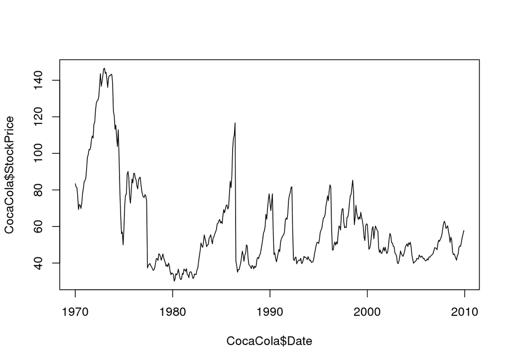

```r
plot(CocaCola$Date, CocaCola$StockPrice, type="l")
```

Around what year did Coca-cola has its highest stock price in this time period ? **1973**

Around what year did Coca/Cola has its lowest stock price in this time period ? **1980**

Let’s add the line for Procter & Gamble too. Add the line to a plot in R by using the lines function. Add a color for the lines to distinguish them. Draw a vertical line at a certain date with the function abline()

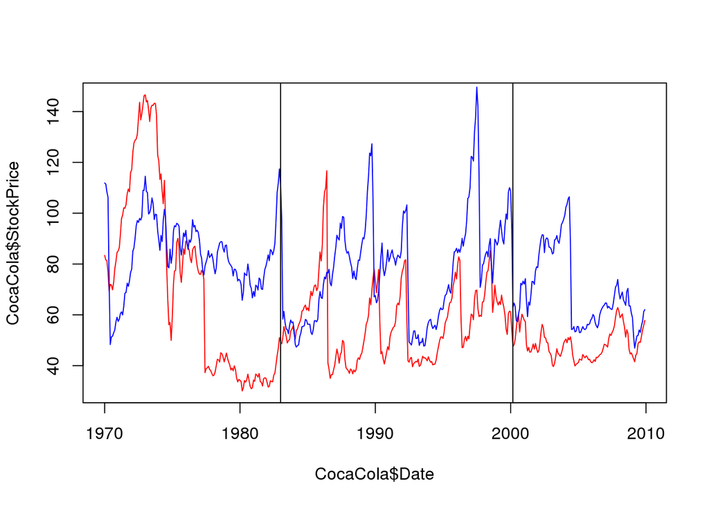

```r
plot(CocaCola$Date, CocaCola$StockPrice, type="l", col="red")
lines(ProcterGamble$Date, ProcterGamble$StockPrice, col="blue")
abline(v=as.Date(c("2000-03-01")))
abline(v=as.Date(c("1983-01-01")))
```

In March of 2000, the technology bubble burst, and a stock market crash occurred. According to this plot, which company’s stock dropped more? **Procter & Gamble**

Around 1983, the stock for one of these companies (CocaCola or Procter & Gamble) was goinig up, while the other was going down. Which one was going up? **Coca-Cola**

In the time period shown in the plot, which stock generally has lower values? **Coca-Cola**

### Problem 3 - Visualizing Stock Dynamics 1995-2005

Let’s take a look at how the stock prices changed from 1995-2005 for all five companies.

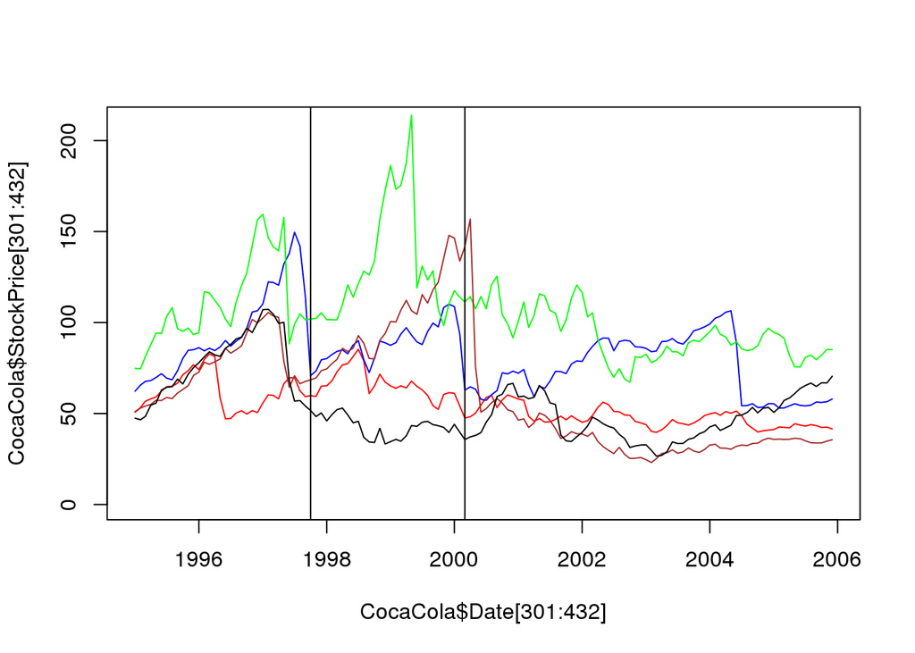

```r
plot(CocaCola$Date[301:432], CocaCola$StockPrice[301:432],type="l",col="red",ylim=c(0,210))
lines(ProcterGamble$Date[301:432], ProcterGamble$StockPrice[301:432],col="blue")
lines(IBM$Date[301:432], IBM$StockPrice[301:432], col="green")
lines(GE$Date[301:432], GE$StockPrice[301:432], col="brown")
lines(Boeing$Date[301:432], Boeing$StockPrice[301:432], col="black")
abline(v=as.Date(c("2000-03-01")))
abline(v=as.Date(c("1997-10-01")))
```

Which stock fell the most right after thge technology bubble burst in March 2000? **GE**

Which stock reaches the highest value in the time period 1995-2005? **IBM**

In October 1997 there was a global stock market crash that was caused by an economic crisis in Asia. comparing September 1997 to November 1997, which companies saw a decreasing trend in their stock price? **Procter & Gamble and Boeing**

In the last two years of this time period (2004 and 2005) which stock seems to be performing the best, in terms of increasing stock price? **Boeing**

### Problem 4 - Monthly Trends

Let’s see if stocks tend to be higher or lower during certain months. Use the tapply command to calculate the mean stock price of IBM, sorted by months.

```r
mean(IBM$StockPrice)
```

```
## [1] 144.375
```

```r
tapply(IBM$StockPrice, months(IBM$Date), mean)
```

```
##     April    August  December  February   January      July      June
##  152.1168  140.1455  140.7593  152.6940  150.2384  139.0670  139.0907
##     March       May  November   October September
##  152.4327  151.5022  138.0187  137.3466  139.0885
```

In which months has IBM historically had a higher stock price? **Jan, Feb, Mar, Apr, May**

```r
tapply(CocaCola$StockPrice, months(CocaCola$Date), mean)
```

```
##     April    August  December  February   January      July      June
##  62.68888  58.88014  59.73223  60.73475  60.36849  58.98346  60.81208
##     March       May  November   October September
##  62.07135  61.44358  59.10268  57.93887  57.60024
```

```r
tapply(GE$StockPrice, months(GE$Date), mean)
```

```
##     April    August  December  February   January      July      June
##  64.48009  56.50315  59.10217  62.52080  62.04511  56.73349  56.46844
##     March       May  November   October September
##  63.15055  60.87135  57.28879  56.23897  56.23913
```

```r
tapply(ProcterGamble$StockPrice, months(ProcterGamble$Date), mean)
```

```
##     April    August  December  February   January      July      June
##  77.68671  76.82266  78.29661  79.02575  79.61798  76.64556  77.39275
##     March       May  November   October September
##  77.34761  77.85958  78.45610  76.67903  76.62385
```

```r
tapply(Boeing$StockPrice, months(Boeing$Date), mean)
```

```
##     April    August  December  February   January      July      June
##  47.04686  46.86311  46.17315  46.89223  46.51097  46.55360  47.38525
##     March       May  November   October September
##  46.88208  48.13716  45.14990  45.21603  46.30485
```

GE and Coca-Cola both have their highest average stock price in the same month. Which month is this? **April**

For the months of December and January, every company’s averages stock is higher in one month and lower in the other. In which month are the stock prices lower? **December**